### Resolução das equações de modelos mistos com grupos de pais desconhecidos (UPG)

##### 1) Resolução direta (R)

##### 2) Método iterativo (BLUPF90+)

**Autor:** Eula Carrara (eulacarrara@gmail.com)  
**Criado em:** 22-Feb-2025  
**Modificado em:** 15-Mar-2025  
**Teoria:** notas de aula Dr. Daniela Lourenco, UGA, 2025  
**Exemplo numérico retirado de** tutorial_blupf90.pdf  
**Pacotes R exigidos:** igraph, MASS, optiSel, tidyverse

```r
install.packages(c("igraph", "MASS", "optiSel", "tidyverse"))
```

Considerando um individuo **a**, filho de **s** e **d**,

$$\begin{array}{c}
s_i \quad \quad d_i \\
\backslash \quad \, / \\
\, a_i
\end{array}$$

o seu valor genético esperado será:

- **se ambos pais conhecidos:** $a_i = \frac{a_{s_i} + a_{d_i}}{2}$
- **se apenas pai conhecido:** $a_i = \frac{a_{s_i} + 0}{2}$
- **se apenas mãe conhecida:** $a_i = \frac{0 + a_{d_i}}{2}$
- **se ambos pais desconhecidos:** $a_i = \frac{0 + 0}{2}$

Ou seja, o valor genético de um pai/mãe desconhecido é igual a zero. O que não condiz com a realidade.  
Uma maneira de preencher essas lacunas na genealogia é construir grupos de pais desconhecidos (UPG; ou pais fantasmas, ou grupo genético):

- **apenas pai conhecido:** $a_i = \frac{a_{s_i} + \boldsymbol{\mathit{UPG_i}}}{2}$
- **apenas mãe conhecida:** $a_i = \frac{\boldsymbol{\mathit{UPG_i}} + a_{d_i}}{2}$
- **ambos pais desconhecidos:** $a_i = \frac{\boldsymbol{\mathit{UPG_i}} + \boldsymbol{\mathit{UPG_i}}}{2}$

**Como formar UPGs?**  
Utilizando informacoes de raça, ano de nascimento, sexo, país, etc…  
UPGs não são animais! São tratados, na maioria das vezes, como um efeito fixo no modelo.

##### Modelo animal misto

O modelo animal misto pode ser descrito como:  
$y = Xb + Za + e$

em que:  
- `y` é o vetor de fenótipos,  
- `b` é o vetor de efeitos fixos,  
- `a` é o vetor de efeitos genéticos aditivos diretos (valor genético),  
- `X` e `Z` relacionam `b` e `a` à `y`,  
- `e` é o vetor de resíduos.

##### Modelo animal misto, mas com **UPG**:

$y = Xb + \mathbf{\mathit{ZQg}} + Za + e$

em que:  
- `Q` é a matriz que relaciona os animais aos UPGs  
- `g` é o efeito dos UPG.

Então precisamos construir `Q`. Como?  
A matriz `Q` é construída com as frações de contribuição de cada UPG nos valores genéticos esperados dos indivíduos relacionados aos UPG.

##### Exemplo de construção da matriz Q:

**Genealogia:**

```
##   ID Sire Dam
## 1 a1   g2  a4
## 2 a2   g3  a1
## 3 a3   g3  a1
## 4 a4   g1  g1
## 5 a5   a3  a6
## 6 a6   g3  g3
```

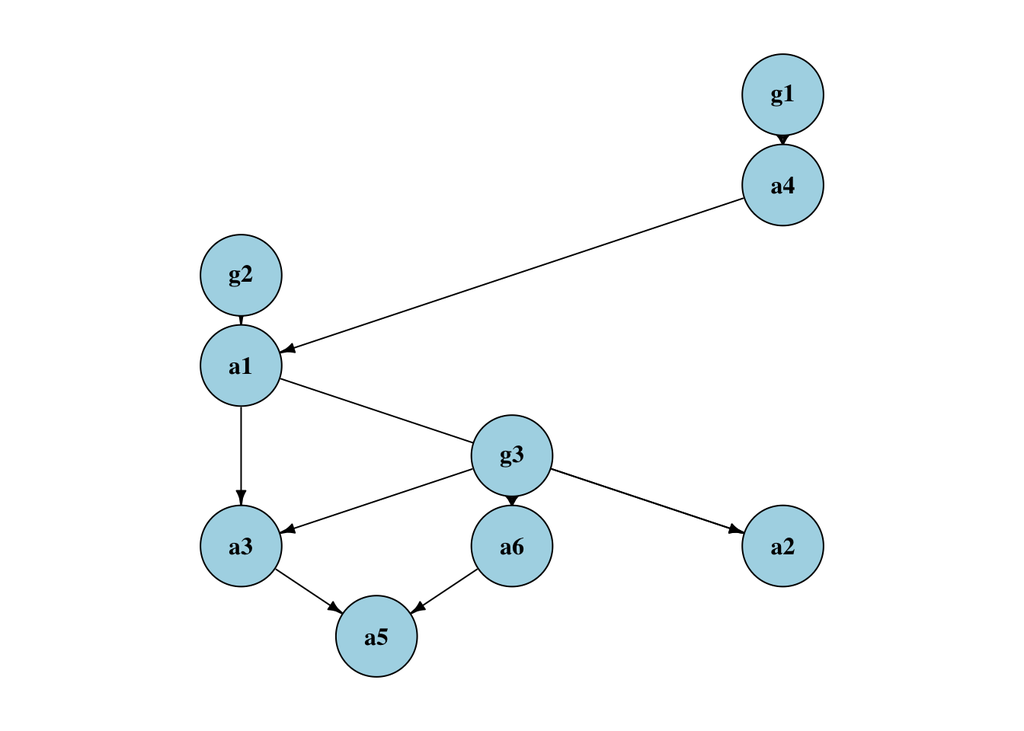

Primeiro, precisamos colocar todos os valores genéticos esperados em função dos UPG:

**Definindo os valores genéticos esperados em função dos UPG**
$$\begin{aligned}
E(a_4) &= \frac{1}{2} \cdot g_1 + \frac{1}{2} \cdot g_1 = g_1 \\
\\[0.1cm]
E(a_1) &= \frac{1}{2} \cdot g_2 + \frac{1}{2} \cdot E(a_4) =
\frac{1}{2} g_1 + \frac{1}{2} g_2 \\
\\[0.1cm]
E(a_3) &= \frac{1}{2} \cdot g_3 + \frac{1}{2} \cdot E(a_1) =
\frac{1}{4} g_1 + \frac{1}{4} g_2 + \frac{1}{2} g_3 \\
\\[0.1cm]
E(a_6) &= \frac{1}{2} \cdot g_3 + \frac{1}{2} \cdot g_3 = g_3 \\
\\[0.1cm]
E(a_5) &= \frac{1}{2} \cdot E(a_3) + \frac{1}{2} \cdot E(a_6) =
\frac{1}{8} g_1 + \frac{1}{8} g_2 + \frac{3}{4} g_3 \\
\\[0.1cm]
E(a_2) &= \frac{1}{2} \cdot g_3 + \frac{1}{2} \cdot E(a_1) =
\frac{1}{4} g_1 + \frac{1}{4} g_2 + \frac{1}{2} g_3
\end{aligned}$$
**Reorganizando e colocando zero nos grupos faltantes** (apenas para melhor visualização)
$$\begin{aligned}
E(a_1) &= \frac{1}{2} \cdot g_1 + \frac{1}{2} \cdot g_2 + 0 \cdot
g_3 \\
\\[0.1cm]
E(a_2) &= \frac{1}{4} \cdot g_1 + \frac{1}{4} \cdot g_2 +
\frac{1}{2} \cdot g_3 \\
\\[0.1cm]
E(a_3) &= \frac{1}{4} \cdot g_1 + \frac{1}{4} \cdot g_2 +
\frac{1}{2} \cdot g_3 \\
\\[0.1cm]
E(a_4) &= 1 \cdot g_1 + 0 \cdot g_2 + 0 \cdot g_3 \\
\\[0.1cm]
E(a_5) &= \frac{1}{8} \cdot g_1 + \frac{1}{8} \cdot g_2 +
\frac{3}{4} \cdot g_3 \\
\\[0.1cm]
E(a_6) &= 0 \cdot g_1 + 0 \cdot g_2 + 1 \cdot g_3
\end{aligned}$$

**Matriz Q com as frações de cada UPG**
$$\begin{bmatrix}
1/2 & 1/2 & 0 \\
1/4 & 1/4 & 1/2 \\
1/4 & 1/4 & 1/2 \\
1 & 0 & 0 \\
1/8 & 1/8 & 3/4 \\
0 & 0 & 1
\end{bmatrix}$$

Essa é a matriz `Q` que será incorporada nas equações de modelos mistos.

#### Exemplo da resolução das equações de modelos mistos considerando UPG

##### Resolução via programa R, passo a passo

**Dados**

```r
data1 <- data.frame(
  ID = c('ID006', 'ID009', 'ID012', 'ID007', 'ID010', 'ID013', 'ID008', 'ID011', 'ID014', 'ID015'),
  A = c('A', 'A', 'A', 'B', 'B', 'B', 'C', 'C', 'C', 'C'),
  S = c(1, 2, 1, 2, 1, 2, 1, 2, 1, 2),
  cov = c(1.0, 1.0, 2.0, 2.0, 1.0, 2.0, 2.0, 1.0, 1.0, 2.0),
  obs = c(3.0, 2.0, 4.0, 6.0, 3.0, 6.0, 6.0, 6.0, 8.0, 4.0)
)
print(data1)
```

```
##       ID A S cov obs
## 1  ID006 A 1   1   3
## 2  ID009 A 2   1   2
## 3  ID012 A 1   2   4
## 4  ID007 B 2   2   6
## 5  ID010 B 1   1   3
## 6  ID013 B 2   2   6
## 7  ID008 C 1   2   6
## 8  ID011 C 2   1   6
## 9  ID014 C 1   1   8
## 10 ID015 C 2   2   4
```

**Genealogia sem UPG**

```r
pedigree <- data.frame(
  ID = c('ID001', 'ID002', 'ID003', 'ID004', 'ID005', 'ID006', 'ID007', 'ID008', 'ID009', 'ID010', 'ID011', 'ID012', 'ID013', 'ID014', 'ID015'),
  Sire = c(NA, NA, NA, NA, NA, NA, 'ID002', 'ID001', 'ID002', 'ID007', 'ID007', 'ID011', 'ID011', 'ID009', 'ID011'),
  Dam = c(NA, NA, NA, NA, NA, NA, 'ID005', 'ID004', 'ID003', 'ID006', 'ID004', 'ID008', 'ID010', 'ID013', 'ID010')
)
print(pedigree)
```

```
##       ID  Sire   Dam
## 1  ID001  <NA>  <NA>
## 2  ID002  <NA>  <NA>
## 3  ID003  <NA>  <NA>
## 4  ID004  <NA>  <NA>
## 5  ID005  <NA>  <NA>
## 6  ID006  <NA>  <NA>
## 7  ID007 ID002 ID005
## 8  ID008 ID001 ID004
## 9  ID009 ID002 ID003
## 10 ID010 ID007 ID006
## 11 ID011 ID007 ID004
## 12 ID012 ID011 ID008
## 13 ID013 ID011 ID010
## 14 ID014 ID009 ID013
## 15 ID015 ID011 ID010
```

**Genealogia com UPG**

```r
pedigree_upg <- data.frame(
  ID = c('ID001', 'ID002', 'ID003', 'ID004', 'ID005', 'ID006', 'ID007', 'ID008', 'ID009', 'ID010', 'ID011', 'ID012', 'ID013', 'ID014', 'ID015'),
  Sire = c('g1', 'g2', 'g1', 'g2', 'g2', 'g1', 'ID002', 'ID001', 'ID002', 'ID007', 'ID007', 'ID011', 'ID011', 'ID009', 'ID011'),
  Dam = c('g4', 'g3', 'g3', 'g3', 'g4', 'g3', 'ID005', 'ID004', 'ID003', 'ID006', 'ID004', 'ID008', 'ID010', 'ID013', 'ID010')
)
print(pedigree_upg)
```

```
##       ID  Sire   Dam
## 1  ID001    g1    g4
## 2  ID002    g2    g3
## 3  ID003    g1    g3
## 4  ID004    g2    g3
## 5  ID005    g2    g4
## 6  ID006    g1    g3
## 7  ID007 ID002 ID005
## 8  ID008 ID001 ID004
## 9  ID009 ID002 ID003
## 10 ID010 ID007 ID006
## 11 ID011 ID007 ID004
## 12 ID012 ID011 ID008
## 13 ID013 ID011 ID010
## 14 ID014 ID009 ID013
## 15 ID015 ID011 ID010
```

```r
# Ordenar o pedigree (sem UPG) pelo ID do animal
pedigree <- pedigree[order(pedigree$ID), ]

# Ordenar os dados pelo ID do animal
data1 <- data1[order(data1$ID), ]
```

##### Modelo

$y = Xb + ZQg + Za + e$

##### Equações de modelos mistos

$$\begin{bmatrix}
X'X & 0 & X'Z \\
0 & Q'A^{-1}Q\alpha & -Q'A^{-1}\alpha \\
Z'X & -A^{-1}Q\alpha & Z'Z + A^{-1}\alpha
\end{bmatrix}
*
\begin{bmatrix}
b\\
0\\
Qg + a
\end{bmatrix}
=
\begin{bmatrix}
X'y \\
0 \\
Z'y
\end{bmatrix}$$

##### Elementos das equações de modelos mistos

**Vetor y**

```r
y <- as.matrix(data1$obs)
print(y)
```

```
##       [,1]
##  [1,]    3
##  [2,]    6
##  [3,]    6
##  [4,]    2
##  [5,]    3
##  [6,]    6
##  [7,]    4
##  [8,]    6
##  [9,]    8
## [10,]    4
```

**Matriz X**

```r
library(dplyr)
X <- data1 %>%
  mutate(A_A = ifelse(A == "A", 1, 0),
         A_B = ifelse(A == "B", 1, 0),
         A_C = ifelse(A == "C", 1, 0),
         S_1 = ifelse(S == 1, 1, 0),
         S_2 = ifelse(S == 2, 1, 0)) %>%
  select(A_A, A_B, A_C, S_1, S_2, cov)

X <- as.matrix(X)
print(X)
```

```
##    A_A A_B A_C S_1 S_2 cov
## 1    1   0   0   1   0   1
## 4    0   1   0   0   1   2
## 7    0   0   1   1   0   2
## 2    1   0   0   0   1   1
## 5    0   1   0   1   0   1
## 8    0   0   1   0   1   1
## 3    1   0   0   1   0   2
## 6    0   1   0   0   1   2
## 9    0   0   1   1   0   1
## 10   0   0   1   0   1   2
```

**Matriz Z** (expandindo a Z para todos os animais para somar com a matriz dos numeradores dos relacionamentos $A^{-1}$)

```r
animals <- pedigree$ID   # Lista de animais na genealogia
N <- nrow(data1)         # Número de observações
Np <- length(animals)    # Número de animais na genealogia

Z <- matrix(0, nrow = N, ncol = Np)
for (i in 1:N) {
  animal_index <- match(data1$ID[i], animals)
  Z[i, animal_index] <- 1
}
print(Z)
```

```
##       [,1] [,2] [,3] [,4] [,5] [,6] [,7] [,8] [,9] [,10] [,11] [,12] [,13] [,14] [,15]
##  [1,]    0    0    0    0    0    1    0    0    0     0     0     0     0     0     0
##  [2,]    0    0    0    0    0    0    1    0    0     0     0     0     0     0     0
##  [3,]    0    0    0    0    0    0    0    1    0     0     0     0     0     0     0
##  [4,]    0    0    0    0    0    0    0    0    1     0     0     0     0     0     0
##  [5,]    0    0    0    0    0    0    0    0    0     1     0     0     0     0     0
##  [6,]    0    0    0    0    0    0    0    0    0     0     1     0     0     0     0
##  [7,]    0    0    0    0    0    0    0    0    0     0     0     1     0     0     0
##  [8,]    0    0    0    0    0    0    0    0    0     0     0     0     1     0     0
##  [9,]    0    0    0    0    0    0    0    0    0     0     0     0     0     1     0
## [10,]    0    0    0    0    0    0    0    0    0     0     0     0     0     0     1
```

**Construindo as matrizes A e A inversa** (note que a A inversa é construída utilizando o pedigree sem UPG)

```r
library(optiSel)
# Matriz A
A <- makeA(pedigree)
```

```r
# Mostrando apenas as 5 primeiras linhas/colunas
print(A[1:5, 1:5], digits = 4)
```

```
##       ID001 ID002 ID003 ID004 ID005
## ID001     1     0     0     0     0
## ID002     0     1     0     0     0
## ID003     0     0     1     0     0
## ID004     0     0     0     1     0
## ID005     0     0     0     0     1
```

```r
# Matriz A inversa
Ainv <- solve(A)
```

```r
# Mostrando apenas as 5 primeiras linhas/colunas
print(Ainv[1:5, 1:5], digits = 4)
```

```
##       ID001 ID002 ID003 ID004 ID005
## ID001   1.5   0.0   0.0   0.5   0.0
## ID002   0.0   2.0   0.5   0.0   0.5
## ID003   0.0   0.5   1.5   0.0   0.0
## ID004   0.5   0.0   0.0   2.0   0.0
## ID005   0.0   0.5   0.0   0.0   1.5
```

**Matriz Q**  
- Função para computar a matriz Q:

```r
n_UPG = 4

compute_expectation <- function(pedigree, N) {
  expectations <- list()

  base_groups <- unique(c(pedigree$Sire, pedigree$Dam))
  base_groups <- base_groups[grepl("^g[0-9]+$", base_groups)]

  for (group in base_groups) {
    expectations[[group]] <- setNames(as.list(rep(0, N)), paste0("g", 1:N))
    expectations[[group]][[group]] <- 1
  }

  get_expectation <- function(id) {
    if (!is.null(expectations[[id]])) {
      return(expectations[[id]])
    }

    row <- pedigree[pedigree$ID == id, ]
    if (nrow(row) == 0) {
      return(setNames(as.list(rep(0, N)), paste0("g", 1:N)))
    }

    sire_exp <- get_expectation(row$Sire)
    dam_exp <- get_expectation(row$Dam)

    expectations[[id]] <- setNames(lapply(1:N, function(i) {
      (1/2) * sire_exp[[paste0("g", i)]] + (1/2) * dam_exp[[paste0("g", i)]]
    }), paste0("g", 1:N))

    return(expectations[[id]])
  }

  animals <- pedigree$ID[grepl("^ID[0-9]+$", pedigree$ID)]
  for (animal in animals) {
    expectations[[animal]] <- get_expectation(animal)
  }

  return(expectations)
}
```

**Aplicando a função na genealogia com UPG** (formato: ID, Pai, Mãe, Pai/Mãe com UPG)

```r
expectations <- compute_expectation(pedigree_upg, n_UPG)

coefficients <- data.frame(
  ID = names(expectations),
  g1 = sapply(expectations, function(x) x$g1),
  g2 = sapply(expectations, function(x) x$g2),
  g3 = sapply(expectations, function(x) x$g3),
  g4 = sapply(expectations, function(x) x$g4))
```

**Matriz Q final:**

```r
Q <- as.matrix(coefficients[-(1:4), -1])
print(Q)
```

```
##           g1     g2     g3     g4
## ID001 0.5000 0.0000 0.0000 0.5000
## ID002 0.0000 0.5000 0.5000 0.0000
## ID003 0.5000 0.0000 0.5000 0.0000
## ID004 0.0000 0.5000 0.5000 0.0000
## ID005 0.0000 0.5000 0.0000 0.5000
## ID006 0.5000 0.0000 0.5000 0.0000
## ID007 0.0000 0.5000 0.2500 0.2500
## ID008 0.2500 0.2500 0.2500 0.2500
## ID009 0.2500 0.2500 0.5000 0.0000
## ID010 0.2500 0.2500 0.3750 0.1250
## ID011 0.0000 0.5000 0.3750 0.1250
## ID012 0.1250 0.3750 0.3125 0.1875
## ID013 0.1250 0.3750 0.3750 0.1250
## ID014 0.1875 0.3125 0.4375 0.0625
## ID015 0.1250 0.3750 0.3750 0.1250
```

Vamos considerar que os componentes de variância são conhecidos:

Variância aditiva direta: $0.5$

```r
vara <- 0.5
```

Variância residual: $2.0$

```r
vare <- 2.0
```

Portanto, alpha é igual a:

```r
alpha <- vare / vara
print(alpha)
```

```
## [1] 4
```

Temos os elementos individuais das equações de modelos mistos, ou seja, $X$, $Z$, $Q$, $A^{-1}$, $\alpha$ e $y$.

Agora, precisamos calcular cada “bloco”:

$$\begin{bmatrix}
X'X & 0 & X'Z \\
0 & Q'A^{-1}Q\alpha & -Q'A^{-1}\alpha \\
Z'X & -A^{-1}Q\alpha & Z'Z + A^{-1}\alpha
\end{bmatrix}
*
\begin{bmatrix}
b \\
0 \\
Qg + a
\end{bmatrix}
=
\begin{bmatrix}
X'y \\
0 \\
Z'y
\end{bmatrix}$$

$$\begin{bmatrix}
\text{block11} & \text{block12} & \text{block13} \\
\text{block21} & \text{block22} & \text{block23} \\
\text{block31} & \text{block32} & \text{block33}
\end{bmatrix}
*
\begin{bmatrix}
b \\
0 \\
Qg + a
\end{bmatrix}
=
\begin{bmatrix}
\text{block1} \\
\text{block2} \\
\text{block3}
\end{bmatrix}$$

Lembrando que LHS * sol = RHS

**LHS - lado esquerdo das equações de modelos mistos**

```r
block_11 <- t(X) %*% X
block_12 <- matrix(0, nrow = nrow(block_11), ncol = ncol(Q))
block_13 <- t(X) %*% Z

block_21 <- matrix(0, nrow = ncol(Q), ncol = nrow(block_11))
block_22 <- t(Q) %*% Ainv %*% Q * alpha
block_23 <- -t(Q) %*% Ainv * alpha

block_31 <- t(Z) %*% X
block_32 <- -Ainv %*% Q * alpha
block_33 <- t(Z) %*% Z + Ainv * alpha

LHS <- rbind(
  cbind(block_11, block_12, block_13),
  cbind(block_21, block_22, block_23),
  cbind(block_31, block_32, block_33))
dimnames(LHS) <- NULL
```

```r
# Mostrando apenas as 5 primeiras linhas/colunas
print(LHS[1:5, 1:5], digits = 4)
```

```
##      [,1] [,2] [,3] [,4] [,5]
## [1,]    3    0    0    2    1
## [2,]    0    3    0    1    2
## [3,]    0    0    4    2    2
## [4,]    2    1    2    5    0
## [5,]    1    2    2    0    5
```

**RHS - lado direito das equações de modelos mistos**

```r
block_1 <- t(X) %*% y
block_2 <- matrix(0, nrow = ncol(Q), ncol = ncol(y))
block_3 <- t(Z) %*% y

RHS <- rbind(block_1, block_2, block_3)
dimnames(RHS) <- NULL
```

```r
# Mostrando apenas as 5 primeiras linhas/colunas
print(RHS[1:5, 1], digits = 4)
```

```
## [1]  9 15 24 24 24
```

Nós precisamos inverter o LHS, pois:  
$\text{sol} = \text{LHS}^{-1} \times \text{RHS}$

```r
solve(LHS)
```

`! system is computationally singular: reciprocal condition number = 1.58711e-18`

Percebam que o LHS **não é uma matriz positiva definida** (`system is computationally singular`), então não possui inversa.  
Precisamos calcular a inversa generalizada…

Vamos usar a função `ginv()` do pacote `MASS`, que calcula a inversa generalizada de Moore-Penrose (uma das mais conhecidas)

```r
library(MASS)
LHSinv <- ginv(LHS)
```

```r
# Mostrando apenas as 5 primeiras linhas/colunas
print(LHSinv[1:5, 1:5], digits = 4)
```

```
##        [,1]   [,2]   [,3]   [,4]  [,5]
## [1,] 1.4778 0.4631 0.6591 0.9670 1.633
## [2,] 0.4631 0.7888 0.4141 0.6595 1.007
## [3,] 0.6591 0.4141 0.8001 0.6504 1.223
## [4,] 0.9670 0.6595 0.6504 1.0605 1.216
## [5,] 1.6330 1.0065 1.2230 1.2164 2.646
```

Multiplicamos a inversa do LHS pelo RHS e teremos nosso vetor de soluções.

**Soluções finais (R):**

```r
solutions_R <- LHSinv %*% RHS
print(solutions_R)
```

```
##              [,1]
##  [1,] -0.53552906
##  [2,]  1.38930712
##  [3,]  2.13580021
##  [4,]  2.38873040
##  [5,]  0.60084788
##  [6,]  1.02099858
##  [7,] -4.60399744
##  [8,]  2.90828845
##  [9,]  3.30986193
## [10,] -5.00557093
## [11,] -4.79790276
## [12,]  3.12605649
## [13,] -0.62320503
## [14,]  3.09897532
## [15,] -1.05552267
## [16,] -0.67781191
## [17,]  1.02838548
## [18,] -0.84258229
## [19,]  1.27528846
## [20,] -0.05636038
## [21,]  2.04669910
## [22,]  0.54680764
## [23,]  1.16463449
## [24,]  1.34945546
## [25,]  0.79807885
```

A ordem das soluções é:
$$\begin{bmatrix}
b \\
g \\
Qg + a
\end{bmatrix}$$
em que:
- `b` é o vetor de soluções para os efeitos fixos
- `g` é o vetor de soluções para os efeitos dos UPG (também fixos aqui)
- `Qg + a` é o vetor de valores genéticos.
Reparem que o **valor genético do animal** será o **efeito do UPG (Qg) + valor genético (a)**.

ou seja:

**Vetor de efeitos fixos b**

```r
beta_hat <- solutions_R[1:ncol(X)]
b <- as.matrix(beta_hat)
print(b)
```

```
##            [,1]
## [1,] -0.5355291
## [2,]  1.3893071
## [3,]  2.1358002
## [4,]  2.3887304
## [5,]  0.6008479
## [6,]  1.0209986
```

**Vetor de efeitos dos UPG (g)**

```r
upg_hat <- solutions_R[(ncol(X) + 1):(ncol(X) + ncol(Q))]
g <- as.matrix(upg_hat)
print(g)
```

```
##           [,1]
## [1,] -4.603997
## [2,]  2.908288
## [3,]  3.309862
## [4,] -5.005571
```

**Vetor de efeitos genéticos aditivos diretos - valor genético (Qg+a)**

```r
animal_hat <- solutions_R[(ncol(X) + ncol(Q) + 1):(ncol(X) + ncol(Q) + ncol(Z))]
Qg_a <- as.matrix(animal_hat)
print(Qg_a)
```

```
##              [,1]
##  [1,] -4.79790276
##  [2,]  3.12605649
##  [3,] -0.62320503
##  [4,]  3.09897532
##  [5,] -1.05552267
##  [6,] -0.67781191
##  [7,]  1.02838548
##  [8,] -0.84258229
##  [9,]  1.27528846
## [10,] -0.05636038
## [11,]  2.04669910
## [12,]  0.54680764
## [13,]  1.16463449
## [14,]  1.34945546
## [15,]  0.79807885
```

E essas foram as nossas soluções finais!

##### y predito

Agora, vamos calcular o vetor `y` (y predito) a partir das soluções que encontramos.  
Pra isso, vamos isolar o `y` da primeira e da terceira linha das equações de modelos mistos, pois a segunda linha do RHS é igual a zero.

**Da primeira linha:**
$$X'y = X'Xb + X'Z(Qg+a)$$

```r
rhs1 <- t(X) %*% X %*% b + t(X) %*% Z %*% Qg_a
```

**Da terceira linha:**
$$Z'y = Z'Xb - A^{-1}Q\alpha g + (Z'Z + A^{-1} \alpha)(Qg + a)$$

```r
rhs3 <- t(Z) %*% X %*% b - Ainv %*% Q %*% (alpha * g) + (t(Z) %*% Z + Ainv * alpha) %*% Qg_a
```

**Vamos criar um sistema com essas duas equações, para resolver `y`**
$$\left\{
\begin{aligned}
X'y &= X'bX + X'Z(Qg+a) \\
Z'y &= Z'Xb - A^{-1}Q\alpha g + (Z'Z + A^{-1} \alpha)(Qg
+ a)
\end{aligned}
\right.$$

Qualquer que seja o modelo animal, a parte que multiplica `y` será sempre uma matriz `mxn`. Vamos chamá-la de `M`.  
Da mesma forma, toda a parte depois do sinal de igual, será um vetor `nx1`. Vamos chamá-lo de `c`.

Então, nos temos que $My=c$.

**Matriz M**

```r
M <- rbind(t(X), t(Z))
```

**Vetor c**

```r
c <- rbind(rhs1, rhs3)
```

Resolvendo y…  
Se tentarmos inverter a matriz `M`, veremos que ela não é positiva definida, então precisamos de uma inversa generalizada: `ginv()`.

```r
y_hat <- ginv(M) %*% c

final <- data.frame(y_predito = y_hat, y_original = y)
print(final)
```

```
##    y_predito y_original
## 1          3          3
## 2          6          6
## 3          6          6
## 4          2          2
## 5          3          3
## 6          6          6
## 7          4          4
## 8          6          6
## 9          8          8
## 10         4          4
```

O `y predito` é idêntico ao `y original`.

Isso é fácil para 15 animais. Mas e se tivermos 1 milhão deles?  
Precisamos de um programa **mais eficiente**.

##### Resolução via programa [`BLUPF90+`](https://nce.ads.uga.edu/wiki/doku.php?id=readme.blupf90plus)

Vamos resolver esse mesmo exemplo utilizando os programas da família BLUPF90  
*(Misztal I., Tsuruta S., Lourenco D.A.L., Aguilar I., Legarra A., and Vitezica Z. 2014. Manual for BLUPF90 family of programs.)*.

**Data**  
`ID006 A 1 1.0 3.0`  
`ID009 A 2 1.0 2.0`  
`ID012 A 1 2.0 4.0`  
`ID007 B 2 2.0 6.0`  
`ID010 B 1 1.0 3.0`  
`ID013 B 2 2.0 6.0`  
`ID008 C 1 2.0 6.0`  
`ID011 C 2 1.0 6.0`  
`ID014 C 1 1.0 8.0`  
`ID015 C 2 2.0 4.0`

**Pedigree com UPG**  
`ID001 0 0 -1 -4`  
`ID002 0 0 -2 -3`  
`ID003 0 0 -1 -3`  
`ID004 0 0 -2 -3`  
`ID005 0 0 -2 -4`  
`ID006 0 0 -1 -3`  
`ID007 ID002 ID005 ID002 ID005`  
`ID008 ID001 ID004 ID001 ID004`  
`ID009 ID002 ID003 ID002 ID003`  
`ID010 ID007 ID006 ID007 ID006`  
`ID011 ID007 ID004 ID007 ID004`  
`ID012 ID011 ID008 ID011 ID008`  
`ID013 ID011 ID010 ID011 ID010`  
`ID014 ID009 ID013 ID009 ID013`  
`ID015 ID011 ID010 ID011 ID010`

Aqui nós codificamos os UPG com números negativos ao invés de letras. É uma exigência do programa BLUPF90+!

**Arquivo de parâmetros**  
`DATAFILE`  
`data1.txt`  
`TRAITS`  
`5`  
`FIELDS_PASSED TO OUTPUT`  
`WEIGHT(S)`  
`RESIDUAL_VARIANCE`  
`2.0`  
`EFFECT`  
`2 cross alpha`  
`EFFECT`  
`3 cross alpha`  
`EFFECT`  
`4 cov`  
`EFFECT`  
`1 cross alpha`  
`RANDOM`  
`animal`  
`FILE`  
`ped2.txt`  
`FILE_POS`  
`1 4 5 0 0 # id, pai, mae - com codigos upg`  
`UPG_TYPE`  
`in_ped`  
`INBREEDING`  
`no-inbreeding # desconsidera a endogamia`  
`(CO)VARIANCES`  
`0.5`

Rodamos o programa [`RENUMF90`](https://nce.ads.uga.edu/wiki/doku.php?id=readme.RENUMF90) e então o programa [`BLUPF90+`](https://nce.ads.uga.edu/wiki/doku.php?id=readme.blupf90plus).  
As soluções (arquivo `solutions`) serão:

```r
sol_blup <- data.frame(
  trait = rep(1, 25),
  effect = c(rep(1, 3), rep(2, 2), 3, rep(4, 19)),
  level = c(1,2,3, 1,2, 1, 1:19),
  solution = c(
    -0.09929111, 1.82312339, 2.56875029, 2.43588849, 0.65341111,
    1.01898764, 0.31554213, -1.15906490, 0.54803039, -1.31841690,
    -0.53693713, 0.78918582, 1.56194108, 0.06661379, 0.68188768,
    0.87340751, -1.52607734, 2.63594054, 2.60934675, -5.25998297,
    -1.10486630, -4.38182541, 3.11359067, 2.12479542, -6.15194294
  ))
print(sol_blup)
```

```
##    trait effect level    solution
## 1      1      1     1 -0.09929111
## 2      1      1     2  1.82312339
## 3      1      1     3  2.56875029
## 4      1      2     1  2.43588849
## 5      1      2     2  0.65341111
## 6      1      3     1  1.01898764
## 7      1      4     1  0.31554213
## 8      1      4     2 -1.15906490
## 9      1      4     3  0.54803039
## 10     1      4     4 -1.31841690
## 11     1      4     5 -0.53693713
## 12     1      4     6  0.78918582
## 13     1      4     7  1.56194108
## 14     1      4     8  0.06661379
## 15     1      4     9  0.68188768
## 16     1      4    10  0.87340751
## 17     1      4    11 -1.52607734
## 18     1      4    12  2.63594054
## 19     1      4    13  2.60934675
## 20     1      4    14 -5.25998297
## 21     1      4    15 -1.10486630
## 22     1      4    16 -4.38182541
## 23     1      4    17  3.11359067
## 24     1      4    18  2.12479542
## 25     1      4    19 -6.15194294
```

As soluções do programa `BLUPF90+` possuem a ordem:  
`[vetor de efeitos fixos]`, `[valores genéticos]`, `[efeitos dos UPG]`.  
Vamos colocar na mesma ordem das soluções que obtivemos no programa R, para compararmos.  
Você pode encontrar o ID original do animal no arquivo `renadd04.ped` e corresponder com o arquivo `solutions` para identificar a ordem.

```r
sol_blup$order <- c("A", "B", "C", "S1", "S2", "cov",
                    "ID015", "ID006", "ID007", "ID008", "ID010", "ID009", "ID011", "ID012",
                    "ID013", "ID014", "ID005", "ID002", "ID004", "ID001", "ID003",
                    "g1", "g2", "g3", "g4")

R_blup_order <- c("A", "B", "C", "S1", "S2", "cov",
                   "g1", "g2", "g3", "g4",
                   "ID001", "ID002", "ID003", "ID004", "ID005", "ID006", "ID007", "ID008",
                   "ID009", "ID010", "ID011", "ID012", "ID013", "ID014", "ID015")
```

Reordenando

```r
sol_blup$order <- factor(sol_blup$order, levels = R_blup_order)
sol_blup2 <- sol_blup %>% arrange(order)
```

Soluções finais (BLUPF90+)

```r
solutions_blup <- as.matrix(sol_blup2$solution)
print(solutions_blup)
```

```
##              [,1]
##  [1,] -0.09929111
##  [2,]  1.82312339
##  [3,]  2.56875029
##  [4,]  2.43588849
##  [5,]  0.65341111
##  [6,]  1.01898764
##  [7,] -4.38182541
##  [8,]  3.11359067
##  [9,]  2.12479542
## [10,] -6.15194294
## [11,] -5.25998297
## [12,]  2.63594054
## [13,] -1.10486630
## [14,]  2.60934675
## [15,] -1.52607734
## [16,] -1.15906490
## [17,]  0.54803039
## [18,] -1.31841690
## [19,]  0.78918582
## [20,] -0.53693713
## [21,]  1.56194108
## [22,]  0.06661379
## [23,]  0.68188768
## [24,]  0.87340751
## [25,]  0.31554213
```

Separando os vetores

```r
# Efeitos fixos
beta_hat <- solutions_blup[1:ncol(X)]; b <- as.matrix(beta_hat)
print(beta_hat)
```

```
## [1] -0.09929111  1.82312339  2.56875029  2.43588849  0.65341111  1.01898764
```

```r
# Efeitos UPG
upg_hat <- solutions_blup[(ncol(X) + 1):(ncol(X) + ncol(Q))]; g <- as.matrix(upg_hat)
print(beta_hat)
```

```
## [1] -0.09929111  1.82312339  2.56875029  2.43588849  0.65341111  1.01898764
```

```r
# Valores genéticos
animal_hat <- solutions_blup[(ncol(X) + ncol(Q) + 1):(ncol(X) + ncol(Q) + ncol(Z))]; Qg_a <- as.matrix(animal_hat)
print(beta_hat)
```

```
## [1] -0.09929111  1.82312339  2.56875029  2.43588849  0.65341111  1.01898764
```

As soluções são **diferentes** das obtidas diretamente, pois utilizamos a **inversa generalizada**.  
Ou seja, teremos diferentes soluções, dependendo de qual inversa usarmos.  
Contudo, o nosso `y predito` deve ser igual em ambas predições, pois funções estimáveis são invariantes a escolha da inversa generalizada (isso é tópico para outro post).

Vamos obter o vetor `y predito`, tal qual fizemos para as soluções R.

```r
rhs1 <- t(X) %*% X %*% b + t(X) %*% Z %*% Qg_a
rhs3 <- t(Z) %*% X %*% b - Ainv %*% Q %*% (alpha * g) + (t(Z) %*% Z + Ainv * alpha) %*% Qg_a
```

$My=c$

Matriz M

```r
M <- rbind(t(X), t(Z))
```

Vetor c

```r
c <- rbind(rhs1, rhs3)
```

Resolvendo y

```r
y_hat <- ginv(M) %*% c

final_blup <- data.frame(y_predito = y_hat, y_original = y)
print(final_blup)
```

```
##    y_predito y_original
## 1   2.999027          3
## 2   6.021592          6
## 3   5.976333          6
## 4   1.987161          2
## 5   2.991506          3
## 6   5.996045          6
## 7   4.004215          4
## 8   5.984827          6
## 9   8.044676          8
## 10  4.001232          4
```

#### Vamos comparar os resultados via R e via blupf90!

```r
final_solutions <- data.frame(
                   ID                  = data1$ID,
                   y_original          = data1$obs,
                   y_predito_R         = final$y_predito,
                   y_predito_blupf90   = round(final_blup$y_predito,3),
                   residual_blupf90    = round((final_blup$y_predito - data1$obs),4))
print(final_solutions)
```

```
##       ID y_original y_predito_R y_predito_blupf90 residual_blupf90
## 1  ID006          3           3             2.999          -0.0010
## 2  ID007          6           6             6.022           0.0216
## 3  ID008          6           6             5.976          -0.0237
## 4  ID009          2           2             1.987          -0.0128
## 5  ID010          3           3             2.992          -0.0085
## 6  ID011          6           6             5.996          -0.0040
## 7  ID012          4           4             4.004           0.0042
## 8  ID013          6           6             5.985          -0.0152
## 9  ID014          8           8             8.045           0.0447
## 10 ID015          4           4             4.001           0.0012
```

Percebam que o `y predito` obtido tanto diretamente (`R`) ou iterativamente (`BLUPF90+`) conferem com o `y original`.  
As soluções obtidas via `BLUPF90+` não são exatas, pois foram geradas por um processo iterativo. Contudo, o resíduo é mínimo.